# Exploring Salary and Unemployment Data for Recent Psychology Graduates

Mar Heron

March 13, 2026

```r
# Load any R Packages you may need
library(tidyverse)
library(fivethirtyeight)
```

## Introduction

This project will explore aspects of the *college_recent_grads* dataset within the R package *fivethirtyeight* using graphics made with the help of the *ggplot2* package. The data from the *college_recent_grads* dataset were obtained from American Community Survey Public Use Microdata Sample files from 2010 to 2012. Data were collected from college graduates ages 22 to 28 with only a bachelor’s degree (no master’s or doctorate degrees). Links to the dataset and accompanying information can be found below this section. The variables within this dataset to be explored include the following:

- **major:** College major
- **sample_size:** Sample size of full-time, year-round workers
- **unemployment_rate:** Number of unemployed graduates divided by total number of graduates
- **median:** Median earnings of full-time, year-round workers

[Link to dataset source](https://github.com/fivethirtyeight/data/blob/master/college-majors/readme.md)

[Link to dataset information](https://fivethirtyeight.com/features/the-economic-guide-to-picking-a-college-major/)

## Graphic 1

**Code and output:**

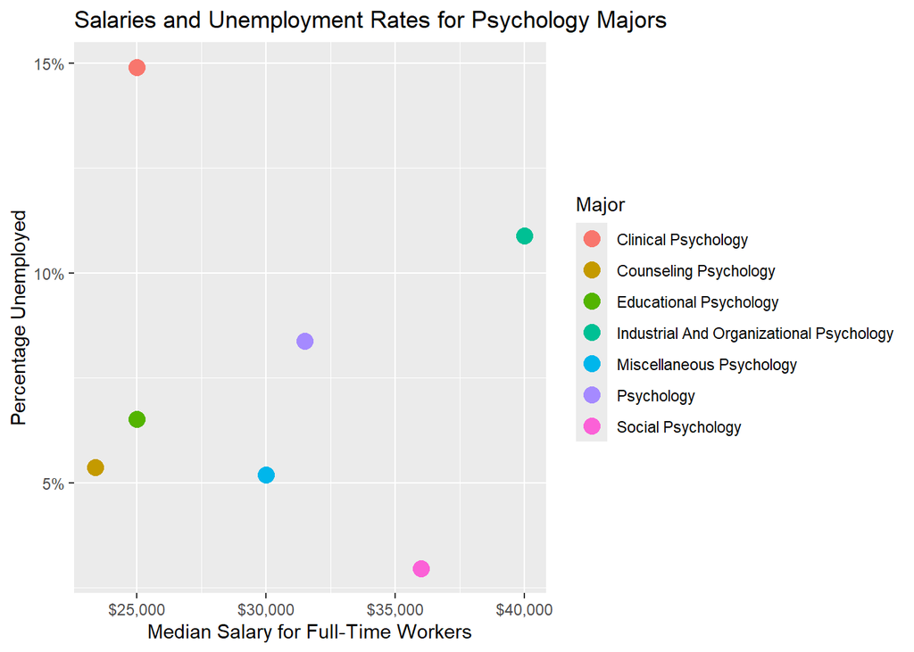

```r
psychology <- filter(college_recent_grads, major %in% c("Social Psychology", "Industrial And Organizational Psychology", "Psychology", "Miscellaneous Psychology", "Educational Psychology", "Clinical Psychology", "Counseling Psychology"))

ggplot(psychology, aes(x = median, y = unemployment_rate, color = major))+
  geom_point(size = 4)+
  labs(title = "Salaries and Unemployment Rates for Psychology Majors", x = "Median Salary for Full-Time Workers", y = "Percentage Unemployed", color = "Major")+
  scale_x_continuous(breaks = seq(20000,40000, by = 5000), labels = c("$20,000", "$25,000", "$30,000", "$35,000", "$40,000"))+
  scale_y_continuous(breaks = seq(0,0.15, by=0.05), labels = c("0%", "5%", "10%", "15%"))
```

## Graphic 2

**Code and output:**

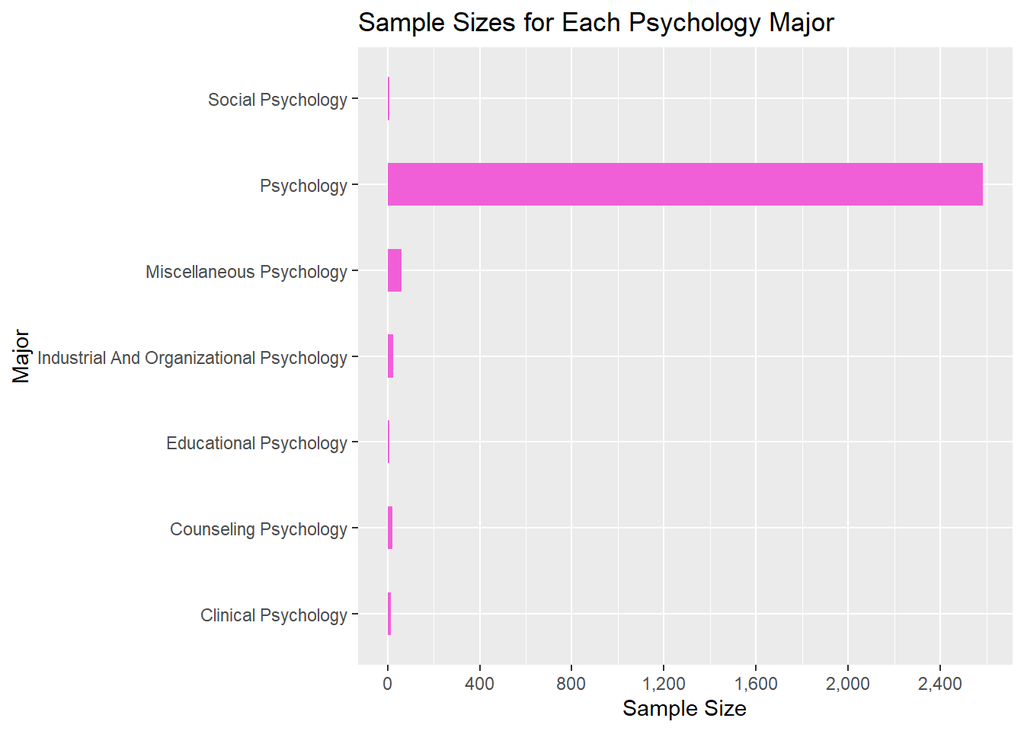

```r
ggplot(psychology, aes(x = sample_size, y = major)) +
geom_col(fill = "#f15fd8", width = 0.5)+
  labs(title = "Sample Sizes for Each Psychology Major", x = "Sample Size", y = "Major")+
  scale_x_continuous(breaks = seq(0, 2600, by = 400), labels = c("0", "400", "800", "1,200", "1,600", "2,000", "2,400"))
```

**Interpretation:** For my second graphic, I chose to create a bar plot looking at each major’s sample size. Because the original *college_recent_grads* dataset’s observations (rows) were individual majors rather than individual students, the sample size could not be reflected using the typical geom_bar() function within the ggplot code, as this function uses the counts of each level of a variable as the length of the corresponding bars. To get around this problem, I used the ggplot function geom_col(), which allowed me to choose the sample size variable to signify the length of each bar instead, while still maintaining all other aspects of a typical bar plot. Looking at this plot, it is clear that the majority of the majors have very small sample sizes and the psychology major has an extremely large sample size in comparison. To be exact, the social, miscellaneous, industrial and organizational, educational, counseling, and clinical psychology majors have sample sizes of 8, 60, 24, 7, 21, and 13 people, respectively. In comparison, the psychology major has a sample size of 2,584 people. Therefore, the median salary data collected about recent graduates from each of these majors could possibly not be entirely accurate.

[Website used to help write the above ggplot code using the geom_col() function](https://sscc.wisc.edu/sscc/pubs/dvr/two-variables.html)

## Conclusion

The graphics explored in this project contribute meaningful information about the *college_recent_grads* dataset, but they do not tell the full story. The data were collected from surveys conducted more than 10 years ago, and therefore are not necessarily reflective of the current day. Additionally, salary information was collected using small samples of recent graduates for the majority of the psychology majors, limiting the generalizability of these results.